# preprocessing

Lawrence Y. Tello

12/10/2020

### Preprocessing

#### Caculating odds ratios & variances

- escalc() spits out the log of the OR
- will need to log the ORs/SMRs not calculated manually

#### Calculating variance with 95% CI’s

[Chochrane provides formulas to calculate variance and CIs: 6.4 Dichotomous outcome data.] (https://training.cochrane.org/handbook/current/chapter-06#section-6-3-2)

For 95% CI:

lower limit = ln(lower confidence limit given for OR) upper limit = ln(upper confidence limit given for OR) intervention effect estimate = lnRR

Standard error:

(upper limit - lower limit) / 3.92

#### Model 1: Fixed effect meta-analysis

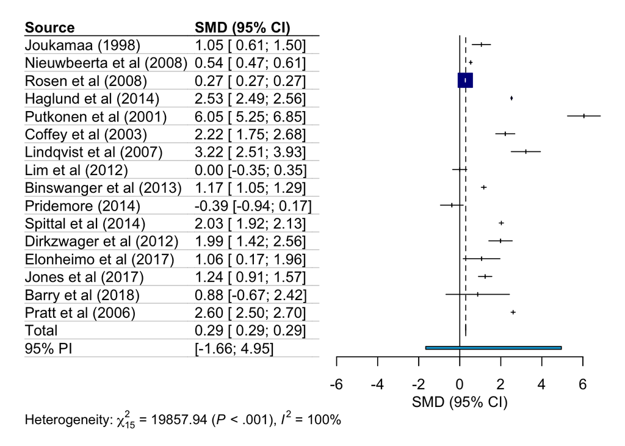

```r
model_1 <- metagen(yi,
                   vi,
                   data=dat,
                   studlab=paste(author),
                   comb.fixed=TRUE,
                   comb.random=FALSE,
                   prediction=TRUE,
                   sm="SMD")
#model_1

forest(model_1,
       layout = "JAMA",
       text.predict = "95% PI",
       col.predict = "#02a4d3"
        )
```

#### Model 2: Random effects meta-analysis combining all

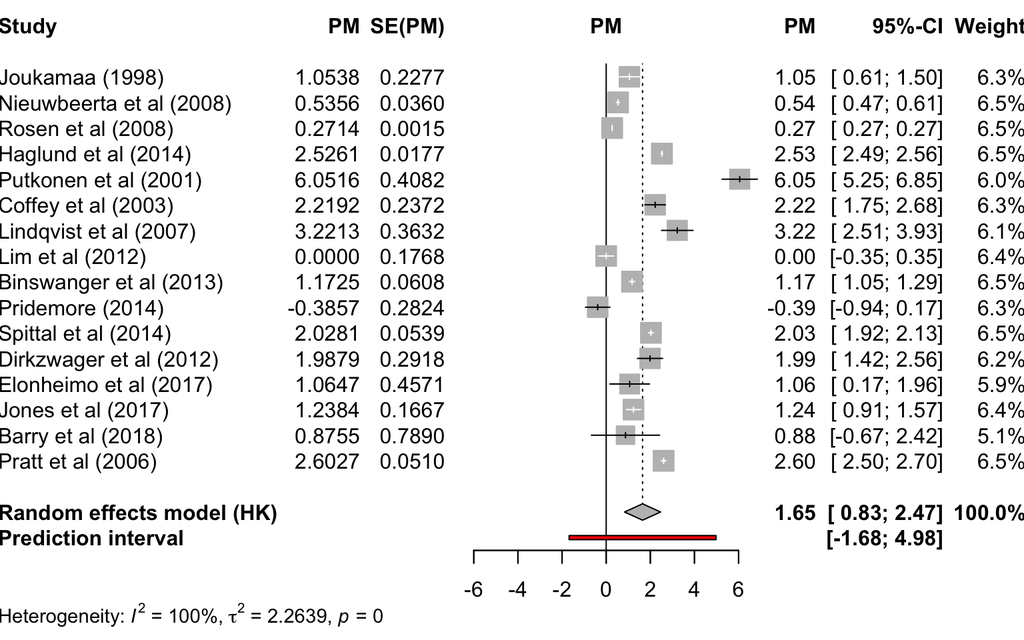

```r
model_2 <- metagen(yi,                      # effect size / TE
                  vi,                       # variance / seTE
                  data = dat,
                  studlab = paste(author),
                  comb.fixed = FALSE,
                  comb.random = TRUE,
                  method.tau = "SJ",
                  hakn = TRUE,
                  prediction = TRUE,
                  sm = "PM")
#model_2
forest(model_2)
```

```r
#funnel(model_2, xlab = "Hedges' g", studlab = TRUE)
```

#### Model 3: Random effects with OR, risk, and hazard ratios only

```r
ratios_only <- dat %>%
  filter(association %in% c("OR", "RR", "HR"))

model_3 <- metagen(yi,                      # effect size / TE
                  vi,                       # variance / seTE
                  data = ratios_only,
                  studlab = paste(author),
                  comb.fixed = FALSE,
                  comb.random = TRUE,
                  method.tau = "SJ",
                  hakn = TRUE,
                  prediction = TRUE,
                  sm = "PM")
model_3
```

```
## Number of studies: k = 9
##
##                               PM            95%-CI    t p-value
## Random effects model (HK) 1.1926 [ 0.3880; 1.9973] 3.42  0.0091
## Prediction interval              [-1.3120; 3.6972]
##
## Quantifying heterogeneity:
##  tau^2 = 1.0004 [0.4414; 3.7720]; tau = 1.0002 [0.6644; 1.9422]
##  I^2 = 100.0%; H = 47.75
##
## Test of heterogeneity:
##         Q d.f. p-value
##  18242.75    8       0
##
## Details on meta-analytical method:
## - Inverse variance method
## - Sidik-Jonkman estimator for tau^2
## - Q-Profile method for confidence interval of tau^2 and tau
## - Hartung-Knapp adjustment for random effects model (df = 8)
## - Prediction interval based on t-distribution (df = 7)
```

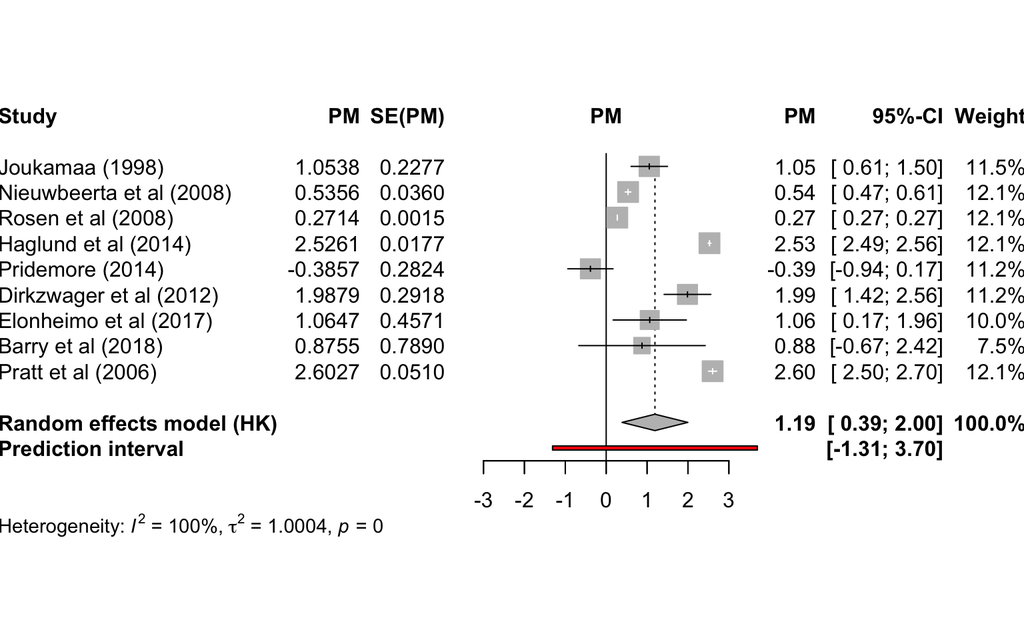

```r
forest(model_3)
```

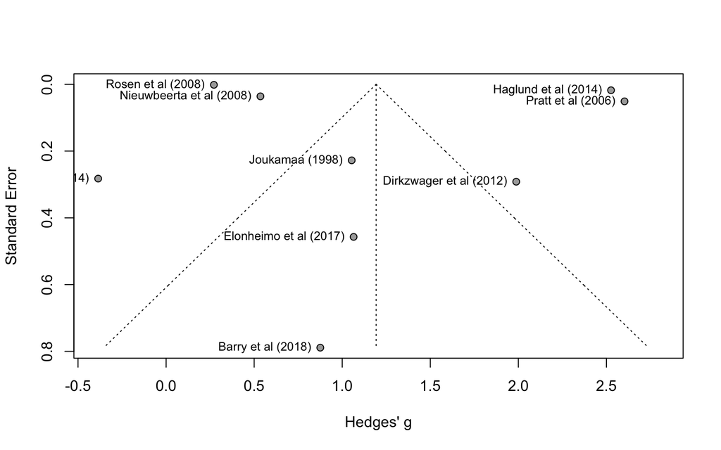

```r
funnel(model_3, xlab = "Hedges' g", studlab = TRUE)
```

#### Model 4: Random effects cohort studies only

```r
cohort_only <- dat %>%
  filter(design == "cohort")

model_4 <- metagen(yi,                      # effect size / TE
                  vi,                       # variance / seTE
                  data = cohort_only,
                  studlab = paste(author),
                  comb.fixed = FALSE,
                  comb.random = TRUE,
                  method.tau = "SJ",
                  hakn = TRUE,
                  prediction = TRUE,
                  sm = "PM")
model_4
```

```
## Number of studies: k = 15
##
##                               PM            95%-CI    t p-value
## Random effects model (HK) 1.7837 [ 0.9626; 2.6048] 4.66  0.0004
## Prediction interval              [-1.4641; 5.0315]
##
## Quantifying heterogeneity:
##  tau^2 = 2.1136 [1.0789; 5.4444]; tau = 1.4538 [1.0387; 2.3333]
##  I^2 = 99.9%; H = 37.66
##
## Test of heterogeneity:
##         Q d.f. p-value
##  19852.20   14       0
##
## Details on meta-analytical method:
## - Inverse variance method
## - Sidik-Jonkman estimator for tau^2
## - Q-Profile method for confidence interval of tau^2 and tau
## - Hartung-Knapp adjustment for random effects model (df = 14)
## - Prediction interval based on t-distribution (df = 13)
```

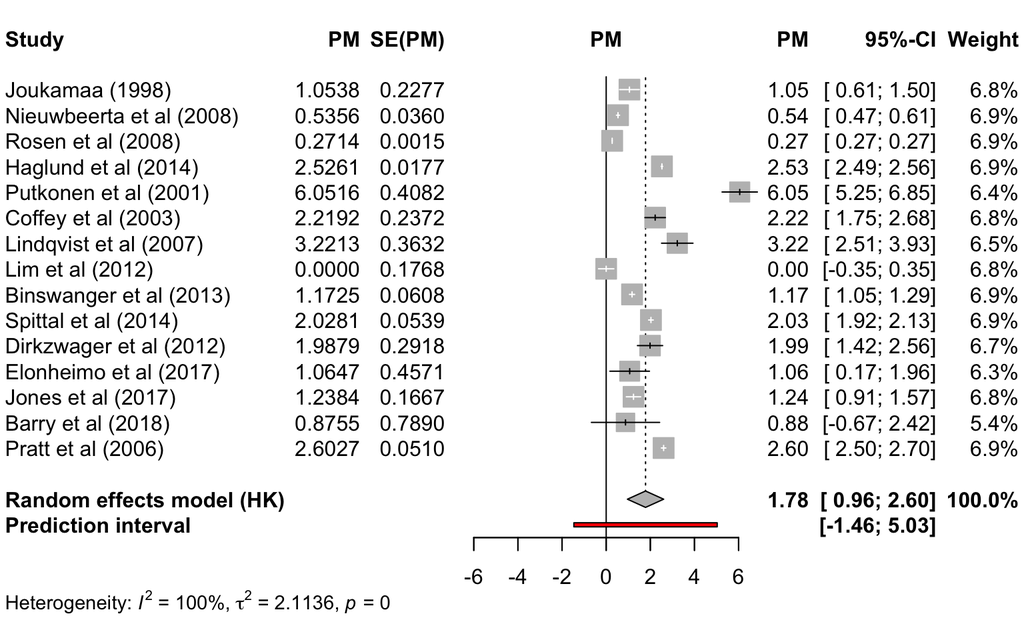

```r
forest(model_4)
```

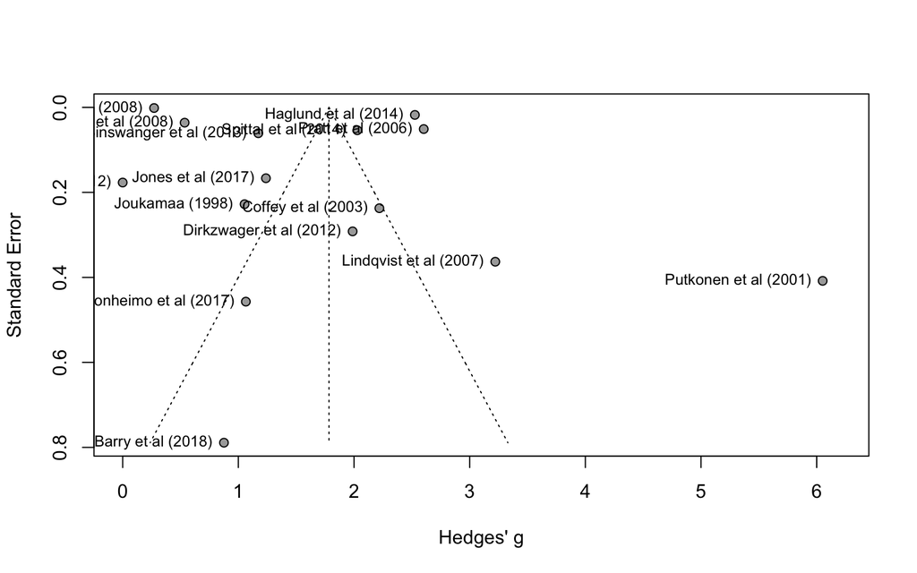

```r
funnel(model_4, xlab = "Hedges' g", studlab = TRUE)
```